# Analisis de Datos R 2

Crystal Puc,Geovani Arias

2025-10-21

### El lenguaje R, vectores

El lenguaje R, como se vió en sesiones anteriores tiene como un tipo de datos importante a los vectores. Los vectores atómicos se pueden generar de diversas formas, por ejemplo usando el comando vector() el cual toma dos parámetros, el tipo de vector atómico (character, double, etc) y el número de valores de ese tipo.

### 1 ACTIVIDADES

Genere un vector de 10 valores tipo integer.

```r
# Crear un vector de 10 enteros del 1 al 10
vector <- c(1, 2, 3, 4, 5, 6, 7, 8, 9, 10)
print(vector)
```

```
##  [1]  1  2  3  4  5  6  7  8  9 10
```

Genere un vector de 15 valores tipo character

```r
# Crear un vector de 15 cadenas de texto
vector_char <- c("rojo", "azul", "verde", "amarillo", "blanco", "negro",
                 "gris", "rosa", "naranja", "morado", "dorado",
                 "plateado", "café", "beige", "turquesa")

print(vector_char)
```

```
##  [1] "rojo"     "azul"     "verde"    "amarillo" "blanco"   "negro"
##  [7] "gris"     "rosa"     "naranja"  "morado"   "dorado"   "plateado"
## [13] "café"     "beige"    "turquesa"
```

### 2 ACTIVIDADES

Genere los siguientes vectores

1.Un vector con diez números enteros e imprímalos

```r
# Generar un vector con diez números enteros
vector_enteros <- c(5, 10, 15, 20, 25, 30, 35, 40, 45, 50)

# Imprimir el vector
print(vector_enteros)
```

```
##  [1]  5 10 15 20 25 30 35 40 45 50
```

2.Un vector con 5 valores lógicos (TRUE o FALSE)

```r
# Crear un vector con 5 valores lógicos
vector_logico <- c(TRUE, FALSE, TRUE, FALSE, TRUE)

# Imprimir el vector
print(vector_logico)
```

```
## [1]  TRUE FALSE  TRUE FALSE  TRUE
```

3.Un vector con 10 nombres de compañeros de la clase.

```r
# Crear un vector con 10 nombres de compañeros
nombres <- c("Crystal", "Juan", "María", "Geovani", "Sofía",
             "Jose", "Aurora", "Melany", "Cindy", "Fernanda")

# Imprimir el vector
print(nombres)
```

```
##  [1] "Crystal"  "Juan"     "María"    "Geovani"  "Sofía"    "Jose"
##  [7] "Aurora"   "Melany"   "Cindy"    "Fernanda"
```

### R como calculadora

R, como se vió en sesiones previas, permite realizar cálculos matemáticos tal cual fuese una calculadora. R permite realizar casí cualquier tipo de cálculo desde aritmética básica hasta el cálculo de la derivada de una función.

### 3 ACTIVIDADES

Hallar las siguientes cantidades usando R

1. cos(2π)

```r
# Calcular cos(2π)
resultado <- cos(2 * pi)

# Imprimir el resultado
print(resultado)
```

```
## [1] 1
```

2. 2π−−√/max(3,2,4,1,8)

```r
# Calcular la expresión sqrt(2*pi) / max(3,2,4,1,8)
resultado <- sqrt(2 * pi) / max(3, 2, 4, 1, 8)

# Imprimir el resultado
print(resultado)
```

```
## [1] 0.3133285
```

3. log10(10000)

```r
# Calcular logaritmo base 10 de 10000
resultado <- log10(10000)
print(resultado)
```

```
## [1] 4
```

### Generando secuencias en R

R permite generar secuencias de valores con el comando seq, el comando seq genera secuencias entre un valor mínimo y máximo y puede generar secuencias de acuerdo a cierto incremento (con el parámetro by=) o una longitud de valores entre mínimo y máximo (con el parámetro length=).

### 4 ACTIVIDADES

1. Una secuencia entre 0 y π con 10 valores.

```r
# Generar secuencia entre 0 y pi con 10 valores
secuencia <- seq(0, pi, length.out = 10)
print(secuencia)
```

```
##  [1] 0.0000000 0.3490659 0.6981317 1.0471976 1.3962634 1.7453293 2.0943951
##  [8] 2.4434610 2.7925268 3.1415927
```

2. Una secuencia de 10 a 8, con incrementos de 0.33.

```r
# Secuencia de 10 a 8 con incrementos de -0.33
secuencia <- seq(10, 8, by = -0.33)
print(secuencia)
```

```
## [1] 10.00  9.67  9.34  9.01  8.68  8.35  8.02
```

3. Una secuencia con valores entre 0 y log2(8) con 20 valores.

```r
# Calcular log base 2 de 8
limite <- log2(8)

# Generar secuencia de 20 valores entre 0 y log2(8)
secuencia <- seq(0, limite, length.out = 20)
print(secuencia)
```

```
##  [1] 0.0000000 0.1578947 0.3157895 0.4736842 0.6315789 0.7894737 0.9473684
##  [8] 1.1052632 1.2631579 1.4210526 1.5789474 1.7368421 1.8947368 2.0526316
## [15] 2.2105263 2.3684211 2.5263158 2.6842105 2.8421053 3.0000000
```

### Graficando funciones con R

Una característica muy potente de Res en la realización de gráficos de funciones.

### 5 ACTIVIDADES

1. y=|x| (valor absoluto de x) de −2 a 2

```r
# Crear vector x de -2 a 2
x <- seq(-2, 2, length.out = 100)  # 100 puntos para suavidad

# Calcular valor absoluto
y <- abs(x)

# Mostrar resultados
print(y)
```

```
##   [1] 2.00000000 1.95959596 1.91919192 1.87878788 1.83838384 1.79797980
##   [7] 1.75757576 1.71717172 1.67676768 1.63636364 1.59595960 1.55555556
##  [13] 1.51515152 1.47474747 1.43434343 1.39393939 1.35353535 1.31313131
##  [19] 1.27272727 1.23232323 1.19191919 1.15151515 1.11111111 1.07070707
##  [25] 1.03030303 0.98989899 0.94949495 0.90909091 0.86868687 0.82828283
##  [31] 0.78787879 0.74747475 0.70707071 0.66666667 0.62626263 0.58585859
##  [37] 0.54545455 0.50505051 0.46464646 0.42424242 0.38383838 0.34343434
##  [43] 0.30303030 0.26262626 0.22222222 0.18181818 0.14141414 0.10101010
##  [49] 0.06060606 0.02020202 0.02020202 0.06060606 0.10101010 0.14141414
##  [55] 0.18181818 0.22222222 0.26262626 0.30303030 0.34343434 0.38383838
##  [61] 0.42424242 0.46464646 0.50505051 0.54545455 0.58585859 0.62626263
##  [67] 0.66666667 0.70707071 0.74747475 0.78787879 0.82828283 0.86868687
##  [73] 0.90909091 0.94949495 0.98989899 1.03030303 1.07070707 1.11111111
##  [79] 1.15151515 1.19191919 1.23232323 1.27272727 1.31313131 1.35353535
##  [85] 1.39393939 1.43434343 1.47474747 1.51515152 1.55555556 1.59595960
##  [91] 1.63636364 1.67676768 1.71717172 1.75757576 1.79797980 1.83838384
##  [97] 1.87878788 1.91919192 1.95959596 2.00000000
```

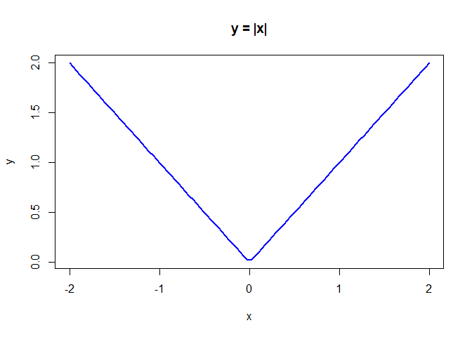

```r
# Opcional: graficar
plot(x, y, type = "l", col = "blue", lwd = 2,
     main = "y = |x|", xlab = "x", ylab = "y")
```

2. y=e−x de 0 a 2 (función exponencial)

```r
# Crear vector x de 0 a 2
x <- seq(0, 2, length.out = 100)  # 100 valores para suavidad

# Calcular la función exponencial y = e^(-x)
y <- exp(-x)

# Mostrar resultados
print(y)
```

```
##   [1] 1.0000000 0.9800007 0.9604013 0.9411939 0.9223707 0.9039239 0.8858460
##   [8] 0.8681297 0.8507677 0.8337529 0.8170784 0.8007374 0.7847232 0.7690293
##  [15] 0.7536492 0.7385767 0.7238057 0.7093301 0.6951439 0.6812415 0.6676171
##  [22] 0.6542653 0.6411804 0.6283572 0.6157905 0.6034751 0.5914060 0.5795783
##  [29] 0.5679871 0.5566277 0.5454956 0.5345860 0.5238947 0.5134171 0.5031491
##  [36] 0.4930865 0.4832251 0.4735609 0.4640900 0.4548085 0.4457127 0.4367987
##  [43] 0.4280630 0.4195020 0.4111123 0.4028903 0.3948328 0.3869364 0.3791979
##  [50] 0.3716142 0.3641822 0.3568988 0.3497611 0.3427661 0.3359110 0.3291930
##  [57] 0.3226093 0.3161574 0.3098344 0.3036380 0.2975654 0.2916143 0.2857822
##  [64] 0.2800668 0.2744656 0.2689765 0.2635971 0.2583254 0.2531590 0.2480960
##  [71] 0.2431343 0.2382718 0.2335065 0.2288365 0.2242599 0.2197749 0.2153795
##  [78] 0.2110721 0.2068508 0.2027139 0.1986598 0.1946867 0.1907931 0.1869774
##  [85] 0.1832380 0.1795733 0.1759820 0.1724624 0.1690133 0.1656332 0.1623206
##  [92] 0.1590743 0.1558929 0.1527752 0.1497198 0.1467255 0.1437911 0.1409153
##  [99] 0.1380971 0.1353353
```

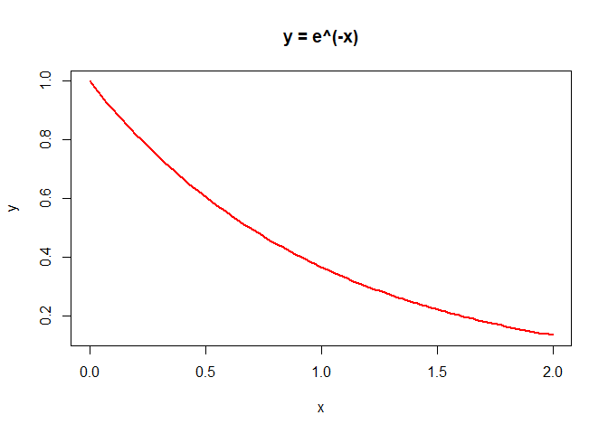

```r
# Opcional: graficar la función
plot(x, y, type = "l", col = "red", lwd = 2,
     main = "y = e^(-x)", xlab = "x", ylab = "y")
```

3. Graficar la función y=x−−√ de 1 a 10.

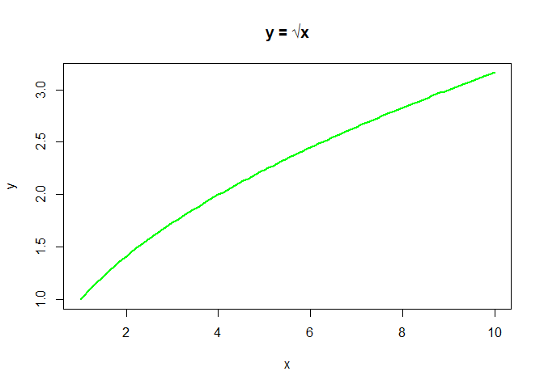

```r
# Crear vector x de 1 a 10
x <- seq(1, 10, length.out = 100)  # 100 puntos para suavidad

# Calcular y = sqrt(x)
y <- sqrt(x)

# Graficar la función
plot(x, y, type = "l", col = "green", lwd = 2,
     main = "y = √x", xlab = "x", ylab = "y")
```